# 9: Data analysis

Feed composition and temperature shape nutrient pressures across global salmon aquaculture locations

Author

Tormey Reimer

Published

5 August 2026

← Previous: Run Atlantic salmon model

Next: Exploring figures →

# 1 Overview

This document does some additional data analysis on the outputs before summarising the numbers needed for the manuscript. In particular, we fit a series of mixed-effects models to determine how much of the variance can be attributed to fixed effects (different feeds), random effects (different farms) and residual effects (Monte-Carlo sampled individual fish).

**Get locations of farms for mapping**

```r
farm_locs <- file.path(input_farm_coords_path, "farm_static_data.qs") %>%
  qread() %>%
  rename(farm_ID = farm_id) %>%
  mutate(
    longitude = st_coordinates(geometry)[, 1],
    latitude = st_coordinates(geometry)[, 2]
  ) %>%
  mutate(
    country = as.factor(country),
    region = case_when(
      country %in% c("Canada", "United States of America") & longitude < -100 ~ "North America (WC)",
      country %in% c("Canada", "United States of America") & longitude < -50 ~ "North America (EC)",
      country %in% c("Ireland", "United Kingdom") ~ "UK & Ireland",
      country %in% c("Iceland", "Faroe Islands") ~ "Iceland & FI",
      country %in% c("Norway", "Finland") ~ "Scandinavia",
      country == "Australia" ~ "Australia",
      country == "Chile" ~ "Chile",
      country == "Russian Federation" ~ NA
    ) %>% as.factor()
  )

temp <- file.path(input_farm_coords_path, "farm_temporal_data.qs") %>%
  qread() %>%
  group_by(farm_id) %>%
  reframe(mean_temp = mean(temp_c, na.rm = T))

farm_locs <- farm_locs %>%
  left_join(temp, by = c("farm_ID" = "farm_id"))
```

# 2 Non-linear fit to temperature

The purpose of this section is two-fold. We know that nutrient waste varies non-linearly with temperature, so the first question is the form (coefficients) this non-linearity takes - this will inform the formula used in the mixed-effects model in the next section (Section 3).

**Get nitrogen data to be analysed**

```r
fish_ends_nitrogen <- here("outputs", "model_run_outputs", "fish_ends_total_nitrogen.qs") %>%
  qread() %>%
  convert_feeds_to_levels() %>%
  select(farm_ID, feed, feed_level, value_perbiom)

# Join with locations for mean farm temperatures
farm_ends_nitrogen <- fish_ends_nitrogen %>%
  left_join(
    farm_locs %>% st_drop_geometry() %>% select(farm_ID, mean_temp),
    by = join_by(farm_ID)
  ) %>%
  group_by(farm_ID, feed, feed_level, mean_temp) %>%
  reframe(mean_value_perbiom = mean(value_perbiom)) %>%
  mutate(
    feed = C(factor(feed), contr.sum),
    feed_level = C(factor(feed_level), contr.sum)
  )
qsave(farm_ends_nitrogen, file.path(data_analysis_path, "farm_ends_nitrogen.qs"))
```

**Get carbon data to be analysed**

```r
fish_ends_carbon <- here("outputs", "model_run_outputs", "fish_ends_total_carbon.qs") %>%
  qread() %>%
  convert_feeds_to_levels() %>%
  select(farm_ID, feed, feed_level, value_perbiom)

# Join with locations for mean farm temperatures
farm_ends_carbon <- fish_ends_carbon %>%
  left_join(
    farm_locs %>% st_drop_geometry() %>% select(farm_ID, mean_temp),
    by = join_by(farm_ID)
  ) %>%
  group_by(farm_ID, feed, feed_level, mean_temp) %>%
  reframe(mean_value_perbiom = mean(value_perbiom)) %>%
  mutate(
    feed = C(factor(feed), contr.sum),
    feed_level = C(factor(feed_level), contr.sum)
  )
qsave(farm_ends_carbon, file.path(data_analysis_path, "farm_ends_carbon.qs"))
```

## 2.1 Nitrogen

**Build non-linear models with varying parameters for nitrogen**

```r
df <- farm_ends_nitrogen %>%
  mutate(
    grp = interaction(feed, feed_level),
    mean_value_perbiom = mean_value_perbiom %>% set_units("g g_fish-1") %>% set_units("kg t_fish-1") %>% drop_units()
  )
grp_levels <- levels(df$grp)
n_grp <- length(grp_levels)

starts <- c(a = 0.02, b = 1.8, c = 40)

# 0. No varying parameters
mod_0 <- nls(
  mean_value_perbiom ~ a * mean_temp^b + c,
  data = df,
  start = list(a = starts['a'], b = starts['b'], c = starts['c'])
)

# 1. Only c varies (a, b shared)
mod_c <- nls(
  mean_value_perbiom ~ a * mean_temp^b + c[grp],
  data = df,
  start = list(a = starts['a'], b = starts['b'], c = rep(starts['c'], n_grp))
)

# 2. c and b vary, a shared
mod_cb <- nls(
  mean_value_perbiom ~ a * mean_temp^b[grp] + c[grp],
  data = df,
  start = list(a = starts['a'], b = rep(starts['b'], n_grp), c = rep(starts['c'], n_grp))
)

# 3. c and a vary, b shared
mod_ca <- nls(
  mean_value_perbiom ~ a[grp] * mean_temp^b + c[grp],
  data = df,
  start = list(a = rep(starts['a'], n_grp), b = starts['b'], c = rep(starts['c'], n_grp))
)

# 4. All three vary
mod_full <- nls(
  mean_value_perbiom ~ a[grp] * mean_temp^b[grp] + c[grp],
  data = df,
  start = list(a = rep(starts['a'], n_grp), b = rep(starts['b'], n_grp), c = rep(starts['c'], n_grp))
)
```

**Compare nested non-linear models for nitrogen**

```r
# varying c is a given (different intercepts)
anova(mod_0, mod_c)      # significant - allowing c to vary improves fit
```

```
Analysis of Variance Table

Model 1: mean_value_perbiom ~ a * mean_temp^b + c
Model 2: mean_value_perbiom ~ a * mean_temp^b + c[grp]
  Res.Df Res.Sum Sq Df Sum Sq F value    Pr(>F)
1  24747     167765
2  24739       1102  8 166663  467778 < 2.2e-16 ***
---
Signif. codes:  0 '***' 0.001 '**' 0.01 '*' 0.05 '.' 0.1 ' ' 1
```

**Compare nested non-linear models for nitrogen**

```r
anova(mod_c, mod_cb)     # significant - allowing b to vary as well as c improves fit
```

```
Analysis of Variance Table

Model 1: mean_value_perbiom ~ a * mean_temp^b + c[grp]
Model 2: mean_value_perbiom ~ a * mean_temp^b[grp] + c[grp]
  Res.Df Res.Sum Sq Df Sum Sq F value    Pr(>F)
1  24739    1101.77
2  24731     476.56  8 625.22  4055.7 < 2.2e-16 ***
---
Signif. codes:  0 '***' 0.001 '**' 0.01 '*' 0.05 '.' 0.1 ' ' 1
```

**Compare nested non-linear models for nitrogen**

```r
anova(mod_c, mod_ca)     # significant - allowing a to vary as well as c improves fit
```

```
Analysis of Variance Table

Model 1: mean_value_perbiom ~ a * mean_temp^b + c[grp]
Model 2: mean_value_perbiom ~ a[grp] * mean_temp^b + c[grp]
  Res.Df Res.Sum Sq Df Sum Sq F value    Pr(>F)
1  24739    1101.77
2  24731     475.21  8 626.56  4075.9 < 2.2e-16 ***
---
Signif. codes:  0 '***' 0.001 '**' 0.01 '*' 0.05 '.' 0.1 ' ' 1
```

**Compare nested non-linear models for nitrogen**

```r
anova(mod_cb, mod_full)  # significant - allowing all three parameters to vary improves fit even more
```

```
Analysis of Variance Table

Model 1: mean_value_perbiom ~ a * mean_temp^b[grp] + c[grp]
Model 2: mean_value_perbiom ~ a[grp] * mean_temp^b[grp] + c[grp]
  Res.Df Res.Sum Sq Df Sum Sq F value    Pr(>F)
1  24731     476.56
2  24723     475.09  8 1.4727  9.5797 2.436e-13 ***
---
Signif. codes:  0 '***' 0.001 '**' 0.01 '*' 0.05 '.' 0.1 ' ' 1
```

**Compare nested non-linear models for nitrogen**

```r
anova(mod_ca, mod_full)  # NOT significant - allowing b to very does not improve fit enough to justify the extra degrees of freedom
```

```
Analysis of Variance Table

Model 1: mean_value_perbiom ~ a[grp] * mean_temp^b + c[grp]
Model 2: mean_value_perbiom ~ a[grp] * mean_temp^b[grp] + c[grp]
  Res.Df Res.Sum Sq Df  Sum Sq F value Pr(>F)
1  24731     475.21
2  24723     475.09  8 0.12745  0.8291 0.5768
```

**Compare AIC values across nitrogen models**

```r
AIC(mod_c, mod_ca, mod_cb, mod_full) %>%
  as_tibble(rownames = "Model") %>%
  arrange(AIC) %>%
  gt()
```

Table 1: AIC comparison of non-linear models for nitrogen with varying parameter structures.

| Model | df | AIC |
| --- | --- | --- |
| mod_ca | 20 | -369488.6 |
| mod_full | 28 | -369479.2 |
| mod_cb | 20 | -369418.6 |
| mod_c | 12 | -348692.0 |

**Supplementary model comparison for nitrogen**

```r
aic_n <- AIC(mod_0, mod_c, mod_ca, mod_cb, mod_full) %>%
  as_tibble(rownames = "Model")

anova_n_0 <- anova(mod_0, mod_c)
anova_n_cb <- anova(mod_c, mod_cb)
anova_n_ca <- anova(mod_c, mod_ca)
anova_n_full_cb <- anova(mod_cb, mod_full)
anova_n_full_ca <- anova(mod_ca, mod_full)

supp_nitrogen <- tribble(
  ~Model,     ~Nested_against, ~Df,                   ~F_value,                     ~P_value,
  "mod_0",    NA,              NA_real_,              NA_real_,                     NA_real_,
  "mod_c",    "mod_0",         anova_n_0$Df[2],       anova_n_0$`F value`[2],       anova_n_0$`Pr(>F)`[2],
  "mod_cb",   "mod_c",         anova_n_cb$Df[2],      anova_n_cb$`F value`[2],      anova_n_cb$`Pr(>F)`[2],
  "mod_ca",   "mod_c",         anova_n_ca$Df[2],      anova_n_ca$`F value`[2],      anova_n_ca$`Pr(>F)`[2],
  "mod_full", "mod_cb",        anova_n_full_cb$Df[2], anova_n_full_cb$`F value`[2], anova_n_full_cb$`Pr(>F)`[2],
  "mod_full", "mod_ca",        anova_n_full_ca$Df[2], anova_n_full_ca$`F value`[2], anova_n_full_ca$`Pr(>F)`[2]
)

supp_nitrogen %>%
  left_join(aic_n, by = "Model") %>%
  select(Model, Nested_against, Df, F_value, P_value, AIC) %>%
  gt() %>%
  fmt_number(columns = c("Df"), decimals = 0) %>%
  fmt_number(columns = c("F_value"), decimals = 2) %>%
  fmt_number(columns = c("P_value"), decimals = 3) %>%
  fmt_number(columns = c("AIC"), decimals = 1)
```

Table 2: ANOVA and AIC comparison of nested non-linear temperature models for nitrogen.

| Model | Nested_against | Df | F_value | P_value | AIC |
| --- | --- | --- | --- | --- | --- |
| mod_0 | NA | NA | NA | NA | 117,610.5 |
| mod_c | mod_0 | 8 | 467,777.56 | 0.000 | −6,758.1 |
| mod_cb | mod_c | 8 | 4,055.68 | 0.000 | −27,484.7 |
| mod_ca | mod_c | 8 | 4,075.91 | 0.000 | −27,554.7 |
| mod_full | mod_cb | 8 | 9.58 | 0.000 | −27,545.3 |
| mod_full | mod_ca | 8 | 0.83 | 0.577 | −27,545.3 |

**Extract and display non-linear model coefficients for nitrogen**

```r
coefs <- coef(mod_ca)
nitrogen_b <- coefs["b"]

coefs_nitrogen <- tibble(
  grp = grp_levels,
  a   = coefs[paste0("a", 1:n_grp)],
  c   = coefs[paste0("c", 1:n_grp)]
) %>%
  mutate(b = coefs["b"]) %>%   # shared across all groups
  separate(grp, into = c("feed", "digest_level"), sep = "\\.") %>%
  select(feed, digest_level, a, b, c)

qsave(coefs_nitrogen, file.path(data_analysis_path, "coefs_nitrogen.qs"))

coefs_nitrogen %>%
  gt() %>%
  fmt_scientific(columns = "a", decimals = 2) %>%
  fmt_number(columns = c("b","c"), decimals = 2)
```

Table 3: Coefficients of the best-fitting non-linear model for nitrogen, with shared exponent b across feed groups.

| feed | digest_level | a | b | c |
| --- | --- | --- | --- | --- |
| animal_dominant_biomar | max | 2.07 × 10<sup>−2</sup> | 1.80 | 5.37 |
| marine_dominant_biomar | max | 1.72 × 10<sup>−2</sup> | 1.80 | 4.48 |
| plant_dominant_biomar | max | 2.39 × 10<sup>−2</sup> | 1.80 | 6.14 |
| animal_dominant_biomar | mean | 3.12 × 10<sup>−2</sup> | 1.80 | 8.06 |
| marine_dominant_biomar | mean | 2.38 × 10<sup>−2</sup> | 1.80 | 6.18 |
| plant_dominant_biomar | mean | 2.74 × 10<sup>−2</sup> | 1.80 | 7.06 |
| animal_dominant_biomar | min | 4.46 × 10<sup>−2</sup> | 1.80 | 11.57 |
| marine_dominant_biomar | min | 3.31 × 10<sup>−2</sup> | 1.80 | 8.61 |
| plant_dominant_biomar | min | 3.55 × 10<sup>−2</sup> | 1.80 | 9.19 |

## 2.2 Carbon

**Build non-linear models with varying parameters for carbon**

```r
df <- farm_ends_carbon %>%
  mutate(
    grp = interaction(feed, feed_level),
    mean_value_perbiom = mean_value_perbiom %>% set_units("g g_fish-1") %>% set_units("kg t_fish-1") %>% drop_units()
  )
grp_levels <- levels(df$grp)
n_grp <- length(grp_levels)

starts <- c(a = 0.1, b = 1.8, c = 40)

# 0. No varying parameters
mod_0 <- nls(
  mean_value_perbiom ~ a * mean_temp^b + c,
  data = df,
  start = list(a = starts['a'], b = starts['b'], c = starts['c'])
)

# 1. Only c varies (a, b shared)
mod_c <- nls(
  mean_value_perbiom ~ a * mean_temp^b + c[grp],
  data = df,
  start = list(a = starts['a'], b = starts['b'], c = rep(starts['c'], n_grp))
)

# 2. c and b vary, a shared
mod_cb <- nls(
  mean_value_perbiom ~ a * mean_temp^b[grp] + c[grp],
  data = df,
  start = list(a = starts['a'], b = rep(starts['b'], n_grp), c = rep(starts['c'], n_grp))
)

# 3. c and a vary, b shared
mod_ca <- nls(
  mean_value_perbiom ~ a[grp] * mean_temp^b + c[grp],
  data = df,
  start = list(a = rep(starts['a'], n_grp), b = starts['b'], c = rep(starts['c'], n_grp))
)

# 4. All three vary
mod_full <- nls(
  mean_value_perbiom ~ a[grp] * mean_temp^b[grp] + c[grp],
  data = df,
  start = list(a = rep(starts['a'], n_grp), b = rep(starts['b'], n_grp), c = rep(starts['c'], n_grp))
)
```

**Compare nested non-linear models for carbon**

```r
# varying c is a given (different intercepts)
anova(mod_c, mod_cb)     # significant - allowing b to vary as well as c improves fit
```

```
Analysis of Variance Table

Model 1: mean_value_perbiom ~ a * mean_temp^b + c[grp]
Model 2: mean_value_perbiom ~ a * mean_temp^b[grp] + c[grp]
  Res.Df Res.Sum Sq Df  Sum Sq F value    Pr(>F)
1  24739   0.068485
2  24731   0.032535  8 0.03595  3415.9 < 2.2e-16 ***
---
Signif. codes:  0 '***' 0.001 '**' 0.01 '*' 0.05 '.' 0.1 ' ' 1
```

**Compare nested non-linear models for carbon**

```r
anova(mod_c, mod_ca)     # significant - allowing a to vary as well as c improves fit
```

```
Analysis of Variance Table

Model 1: mean_value_perbiom ~ a * mean_temp^b + c[grp]
Model 2: mean_value_perbiom ~ a[grp] * mean_temp^b + c[grp]
  Res.Df Res.Sum Sq Df   Sum Sq F value    Pr(>F)
1  24739   0.068485
2  24731   0.032438  8 0.036048  3435.4 < 2.2e-16 ***
---
Signif. codes:  0 '***' 0.001 '**' 0.01 '*' 0.05 '.' 0.1 ' ' 1
```

**Compare nested non-linear models for carbon**

```r
anova(mod_cb, mod_full)  # significant - allowing all three parameters to vary improves fit even more
```

```
Analysis of Variance Table

Model 1: mean_value_perbiom ~ a * mean_temp^b[grp] + c[grp]
Model 2: mean_value_perbiom ~ a[grp] * mean_temp^b[grp] + c[grp]
  Res.Df Res.Sum Sq Df     Sum Sq F value    Pr(>F)
1  24731   0.032535
2  24723   0.032428  8 0.00010735   10.23 2.204e-14 ***
---
Signif. codes:  0 '***' 0.001 '**' 0.01 '*' 0.05 '.' 0.1 ' ' 1
```

**Compare nested non-linear models for carbon**

```r
anova(mod_ca, mod_full)  # NOT significant - allowing b to very does not improve fit enough to justify the extra degrees of freedom
```

```
Analysis of Variance Table

Model 1: mean_value_perbiom ~ a[grp] * mean_temp^b + c[grp]
Model 2: mean_value_perbiom ~ a[grp] * mean_temp^b[grp] + c[grp]
  Res.Df Res.Sum Sq Df     Sum Sq F value Pr(>F)
1  24731   0.032438
2  24723   0.032428  8 9.9088e-06  0.9443 0.4782
```

**Compare AIC values across carbon models**

```r
AIC(mod_c, mod_ca, mod_cb, mod_full) %>%
  as_tibble(rownames = "Model") %>%
  arrange(AIC) %>%
  gt()
```

Table 4: AIC comparison of non-linear models for carbon with varying parameter structures.

| Model | df | AIC |
| --- | --- | --- |
| mod_ca | 20 | -264961.6 |
| mod_full | 28 | -264953.2 |
| mod_cb | 20 | -264887.4 |
| mod_c | 12 | -246482.0 |

**Supplementary model comparison for carbon**

```r
aic_n <- AIC(mod_0, mod_c, mod_ca, mod_cb, mod_full) %>%
  as_tibble(rownames = "Model")

anova_n_0 <- anova(mod_0, mod_c)
anova_n_cb <- anova(mod_c, mod_cb)
anova_n_ca <- anova(mod_c, mod_ca)
anova_n_full_cb <- anova(mod_cb, mod_full)
anova_n_full_ca <- anova(mod_ca, mod_full)

supp_carbon <- tribble(
  ~Model,     ~Nested_against, ~Df,                   ~F_value,                     ~P_value,
  "mod_0",    NA,              NA_real_,              NA_real_,                     NA_real_,
  "mod_c",    "mod_0",         anova_n_0$Df[2],       anova_n_0$`F value`[2],       anova_n_0$`Pr(>F)`[2],
  "mod_cb",   "mod_c",         anova_n_cb$Df[2],      anova_n_cb$`F value`[2],      anova_n_cb$`Pr(>F)`[2],
  "mod_ca",   "mod_c",         anova_n_ca$Df[2],      anova_n_ca$`F value`[2],      anova_n_ca$`Pr(>F)`[2],
  "mod_full", "mod_cb",        anova_n_full_cb$Df[2], anova_n_full_cb$`F value`[2], anova_n_full_cb$`Pr(>F)`[2],
  "mod_full", "mod_ca",        anova_n_full_ca$Df[2], anova_n_full_ca$`F value`[2], anova_n_full_ca$`Pr(>F)`[2]
)

supp_carbon %>%
  left_join(aic_n, by = "Model") %>%
  select(Model, Nested_against, Df, F_value, P_value, AIC) %>%
  gt() %>%
  fmt_number(columns = c("Df"), decimals = 0) %>%
  fmt_number(columns = c("F_value"), decimals = 2) %>%
  fmt_number(columns = c("P_value"), decimals = 3) %>%
  fmt_number(columns = c("AIC"), decimals = 1)
```

Table 5: ANOVA and AIC comparison of nested non-linear temperature models for carbon.

| Model | Nested_against | Df | F_value | P_value | AIC |
| --- | --- | --- | --- | --- | --- |
| mod_0 | NA | NA | NA | NA | 217,933.9 |
| mod_c | mod_0 | 8 | 433,217.76 | 0.000 | 95,451.9 |
| mod_cb | mod_c | 8 | 3,415.87 | 0.000 | 77,046.5 |
| mod_ca | mod_c | 8 | 3,435.41 | 0.000 | 76,972.3 |
| mod_full | mod_cb | 8 | 10.23 | 0.000 | 76,980.7 |
| mod_full | mod_ca | 8 | 0.94 | 0.478 | 76,980.7 |

**Extract and display non-linear model coefficients for carbon**

```r
coefs <- coef(mod_ca)
carbon_b <- coefs["b"]

coefs_carbon <- tibble(
  grp = grp_levels,
  a   = coefs[paste0("a", 1:n_grp)],
  c   = coefs[paste0("c", 1:n_grp)]
) %>%
  mutate(b = coefs["b"]) %>%   # shared across all groups
  separate(grp, into = c("feed", "digest_level"), sep = "\\.") %>%
  select(feed, digest_level, a, b, c)

qsave(coefs_carbon, file.path(data_analysis_path, "coefs_carbon.qs"))

coefs_carbon %>%
  gt() %>%
  fmt_number(columns = "c", decimals = 1) %>%
  fmt_number(columns = c("b","a"), decimals = 2)
```

Table 6: Coefficients of the best-fitting non-linear model for carbon, with shared exponent b across feed groups.

| feed | digest_level | a | b | c |
| --- | --- | --- | --- | --- |
| animal_dominant_biomar | max | 0.11 | 1.87 | 34.7 |
| marine_dominant_biomar | max | 0.10 | 1.87 | 34.5 |
| plant_dominant_biomar | max | 0.13 | 1.87 | 42.4 |
| animal_dominant_biomar | mean | 0.16 | 1.87 | 51.1 |
| marine_dominant_biomar | mean | 0.15 | 1.87 | 49.4 |
| plant_dominant_biomar | mean | 0.17 | 1.87 | 56.2 |
| animal_dominant_biomar | min | 0.23 | 1.87 | 74.2 |
| marine_dominant_biomar | min | 0.22 | 1.87 | 71.7 |
| plant_dominant_biomar | min | 0.24 | 1.87 | 78.7 |

# 3 Variance partitioning

These models are to parition variance in nutrient outputs and examine the effect of changing feed. We use the total value per biomass rather than total value because total value is highly dependent on farm population, which is implied by production statistics rather than modelled.

- Quality crossed with feed, both crossed with location.
- Temperature is a fixed effect (between-location predictor).
- I considered including location as random (intercept) but since there is no between-location variance that isn’t captured by temperature this proved unecessary (singular fit).
- I also considered including the interaction between feed type/level and temperature, but since feed type/level is not mechanistically linked to temperature in the model this seemed unecessary and a huge increase in model complexity. There will likely be a small amount of variation attributable to this: temperature -> feeding response -> ingestion -> calories consumed (differs between feeds) -> weight gain -> feed provided. In the following partitioning model structure this variation will be absorbed into residual (individual) variation, which is already very small.

## 3.1 Nitrogen

**Fit model for nitrogen and save**

```r
# Get within-farm variation
fish_var <- fish_ends_nitrogen %>%
  group_by(farm_ID, feed, feed_level) %>%
  reframe(
    value_perbiom = var(value_perbiom),
    n = n()
  )
V_fish <- with(fish_var, sum((n - 1) * value_perbiom) / sum(n - 1))

# Add power-temperature to farm ends
farm_ends_nitrogen <- farm_ends_nitrogen %>%
  mutate(power_temp = mean_temp ^ nitrogen_b)

# Fit full model
m_full <- lmer(
  mean_value_perbiom ~ feed * feed_level + power_temp + (1 | farm_ID),
  data = farm_ends_nitrogen
)

qsave(m_full, file.path(data_analysis_path, "m_full_Nitrogen.qs"))
```

**Partition variance on the nitrogen model**

```r
fixed_form <- ~ feed * feed_level + power_temp
mm   <- model.matrix(fixed_form, data = farm_ends_nitrogen)
beta <- fixef(m_full)[colnames(mm)]
asgn <- attr(mm, "assign")
lbl  <- attr(terms(fixed_form), "term.labels")

contrib <- vapply(seq_along(lbl), function(j) {
  cols <- which(asgn == j)
  var(as.numeric(mm[, cols, drop = FALSE] %*% beta[cols]))
}, numeric(1))
names(contrib) <- lbl

V_fixed <- var(as.numeric(mm %*% beta))              # total fixed-effect variance
V_loc   <- as.data.frame(VarCorr(m_full))$vcov[1]    # between-location, after temperature
V_total <- V_fixed + V_loc + V_fish                  # total fish-level variance

marg_R2 <- V_fixed / V_total                         # all fixed effects
cond_R2 <- (V_fixed + V_loc) / V_total               # fixed + location

comp <- tibble(
  group  = c(rep("Fixed effects", 4), rep("Random effects", 2)),
  source = c("Feed", "Digestibility", "Feed × digestibility", "Temperature (power)", "Farm ID (between-farm residual)", "Fish (within-farm residual)"),
  variance = c(contrib[["feed"]], contrib[["feed_level"]], contrib[["feed:feed_level"]], contrib[["power_temp"]], V_loc, V_fish)
) %>%
  mutate(pct = variance / V_total * 100)
```

**Display variance results**

```r
comp %>%
  gt(rowname_col = "source", groupname_col = "group") %>%
  cols_label(variance = "Variance", pct = "% of total") %>%
  fmt_scientific(columns = variance, decimals = 2) %>%
  fmt_percent(columns = pct, scale_values = FALSE, decimals = 1) %>%
  tab_source_note(md(sprintf(
    "Marginal R² (fixed) = **%.1f%%** · Conditional R² (fixed + location) = **%.1f%%**",
    marg_R2 * 100, cond_R2 * 100))) %>%
  tab_style(cell_text(weight = "bold"), locations = cells_row_groups()) %>%
  opt_stylize(style = 6, color = "gray")
```

Table 7: Results of the variance partitioning for the nitrogen loading mixed-effects model. Temperature is a co-variate of farm ID, so the ‘Farm ID’ residual refers to any variance between farms NOT captured by temperature directly.

|  | Variance | % of total |
| --- | --- | --- |
| Fixed effects |  |  |
| Feed | 9.68 × 10<sup>−7</sup> | 13.7% |
| Digestibility | 5.31 × 10<sup>−6</sup> | 75.0% |
| Feed × digestibility | 4.54 × 10<sup>−7</sup> | 6.4% |
| Temperature (power) | 3.26 × 10<sup>−7</sup> | 4.6% |
| Random effects |  |  |
| Farm ID (between-farm residual) | 1.50 × 10<sup>−8</sup> | 0.2% |
| Fish (within-farm residual) | 4.12 × 10<sup>−9</sup> | 0.1% |

Marginal R² (fixed) = **99.7%** · Conditional R² (fixed + location) = **99.9%**

## 3.2 Carbon

This model is the same as the above, but for carbon. I expect that the results of the variance partitioning will be pretty much exactly the same.

**Fit model for carbon and save**

```r
# Get within-farm variation
fish_var <- fish_ends_carbon %>%
  group_by(farm_ID, feed, feed_level) %>%
  reframe(
    value_perbiom = var(value_perbiom),
    n = n()
  )
V_fish <- with(fish_var, sum((n - 1) * value_perbiom) / sum(n - 1))

# Add power-temperature to farm ends
farm_ends_carbon <- farm_ends_carbon %>%
  mutate(power_temp = mean_temp ^ carbon_b)

# Fit full model
m_full <- lmer(
  mean_value_perbiom ~ feed * feed_level + power_temp + (1 | farm_ID),
  data = farm_ends_carbon
)

qsave(m_full, file.path(data_analysis_path, "m_full_Carbon.qs"))
```

**Partition variance on the carbon model**

```r
fixed_form <- ~ feed * feed_level + power_temp
mm   <- model.matrix(fixed_form, data = farm_ends_carbon)
beta <- fixef(m_full)[colnames(mm)]
asgn <- attr(mm, "assign")
lbl  <- attr(terms(fixed_form), "term.labels")

contrib <- vapply(seq_along(lbl), function(j) {
  cols <- which(asgn == j)
  var(as.numeric(mm[, cols, drop = FALSE] %*% beta[cols]))
}, numeric(1))
names(contrib) <- lbl

V_fixed <- var(as.numeric(mm %*% beta))              # total fixed-effect variance
V_loc   <- as.data.frame(VarCorr(m_full))$vcov[1]    # between-location, after temperature
V_total <- V_fixed + V_loc + V_fish                  # total fish-level variance

marg_R2 <- V_fixed / V_total                         # all fixed effects
cond_R2 <- (V_fixed + V_loc) / V_total               # fixed + location

comp <- tibble(
  group  = c(rep("Fixed effects", 4), rep("Random effects", 2)),
  source = c("Feed", "Digestibility", "Feed × digestibility", "Temperature (power)", "Farm ID (between-farm residual)", "Fish (within-farm residual)"),
  variance = c(contrib[["feed"]], contrib[["feed_level"]], contrib[["feed:feed_level"]], contrib[["power_temp"]], V_loc, V_fish)
) %>%
  mutate(pct = variance / V_total * 100)
```

**Display variance results**

```r
comp %>%
  gt(rowname_col = "source", groupname_col = "group") %>%
  cols_label(variance = "Variance", pct = "% of total") %>%
  fmt_scientific(columns = variance, decimals = 2) %>%
  fmt_percent(columns = pct, scale_values = FALSE, decimals = 1) %>%
  tab_source_note(md(sprintf(
    "Marginal R² (fixed) = **%.1f%%** · Conditional R² (fixed + location) = **%.1f%%**",
    marg_R2 * 100, cond_R2 * 100))) %>%
  tab_style(cell_text(weight = "bold"), locations = cells_row_groups()) %>%
  opt_stylize(style = 6, color = "gray")
```

Table 8: Results of the variance partitioning for the carbon loading mixed-effects model. Temperature is a co-variate of farm ID, so the ‘Farm ID’ residual refers to any variance between farms NOT captured by temperature directly.

|  | Variance | % of total |
| --- | --- | --- |
| Fixed effects |  |  |
| Feed | 1.53 × 10<sup>−5</sup> | 3.8% |
| Digestibility | 3.72 × 10<sup>−4</sup> | 91.6% |
| Feed × digestibility | 5.63 × 10<sup>−7</sup> | 0.1% |
| Temperature (power) | 1.71 × 10<sup>−5</sup> | 4.2% |
| Random effects |  |  |
| Farm ID (between-farm residual) | 1.08 × 10<sup>−6</sup> | 0.3% |
| Fish (within-farm residual) | 2.19 × 10<sup>−7</sup> | 0.1% |

Marginal R² (fixed) = **99.7%** · Conditional R² (fixed + location) = **99.9%**

# 4 Waste and uneaten feed partitioning

**Calculate proportion of C and N from uneaten feed for the farms with lowest and highest loading**

```r
lowest <- 1858
highest <- 626

c(
  here("outputs", "model_run_outputs", "farm_ends_carbon_uneat.qs"),
  here("outputs", "model_run_outputs", "farm_ends_carbon_excr.qs")
 ) %>%
  map_dfr(qread) %>%
  convert_feeds_to_levels() %>%
  filter(farm_ID %in% c(highest, lowest) & feed == "animal_dominant_biomar" & feed_level == "mean") %>%
  select(farm_ID, feed, feed_level, measure, mean_value_perbiom) %>%
  mutate(mean_value_perbiom = mean_value_perbiom %>% set_units("g g_fish-1") %>% set_units("kg t_fish-1")) %>%
  pivot_wider(names_from = measure, values_from = mean_value_perbiom) %>%
  mutate(total_carbon = carbon_uneat + carbon_excr, prop = carbon_uneat/(carbon_uneat + carbon_excr))
```

```
# A tibble: 2 × 7
  farm_ID feed            feed_level carbon_uneat carbon_excr total_carbon  prop
    <int> <fct>           <fct>       [kg/t_fish] [kg/t_fish]  [kg/t_fish]   [1]
1     626 animal_dominan… mean               20.0        63.5         83.5 0.239
2    1858 animal_dominan… mean               13.1        41.6         54.7 0.240
```

**Calculate proportion of C and N from uneaten feed for the farms with lowest and highest loading**

```r
c(
  here("outputs", "model_run_outputs", "farm_ends_nitrogen_uneat.qs"),
  here("outputs", "model_run_outputs", "farm_ends_nitrogen_excr.qs")
 ) %>%
  map_dfr(qread) %>%
  convert_feeds_to_levels() %>%
  filter(farm_ID %in% c(highest, lowest) & feed == "animal_dominant_biomar" & feed_level == "mean") %>%
  select(farm_ID, feed, feed_level, measure, mean_value_perbiom) %>%
  mutate(mean_value_perbiom = mean_value_perbiom %>% set_units("g g_fish-1") %>% set_units("kg t_fish-1")) %>%
  pivot_wider(names_from = measure, values_from = mean_value_perbiom) %>%
  mutate(total_nitrogen = nitrogen_uneat + nitrogen_excr, prop = nitrogen_uneat/(nitrogen_uneat + nitrogen_excr))
```

```
# A tibble: 2 × 7
  farm_ID feed      feed_level nitrogen_uneat nitrogen_excr total_nitrogen  prop
    <int> <fct>     <fct>         [kg/t_fish]   [kg/t_fish]    [kg/t_fish]   [1]
1     626 animal_d… mean                 2.35         11.0           13.3  0.177
2    1858 animal_d… mean                 1.54          7.18           8.73 0.177
```

# 5 Misc numbers for paper

This section prints some miscellaneous numbers to be used in the final manuscript.

**Some quick numbers - carbon**

```r
farm_ends_carbon %>%
  mutate(mean_value_perbiom = mean_value_perbiom %>% set_units("g g_fish-1") %>% set_units("kg t_fish-1") %>% drop_units()) %>%
  group_by(feed, feed_level) %>%
  reframe(
    mean = mean(mean_value_perbiom),
    min = min(mean_value_perbiom),
    max = max(mean_value_perbiom)
  ) %>%
  gt() %>%
  fmt_number(
    columns = c(mean, min, max),
    decimals = 3
  ) %>%
  cols_label(
    feed = "Feed", feed_level = "Digest.",
    mean = "Mean", max = "Max", min = "Min"
  )
```

Table 9: Mean, min and max per-biomass values of total carbon (kg C t fish-1) across all farms.

| Feed | Digest. | Mean | Min | Max |
| --- | --- | --- | --- | --- |
| animal_dominant_biomar | max | 43.054 | 36.980 | 56.363 |
| animal_dominant_biomar | mean | 63.590 | 54.739 | 83.528 |
| animal_dominant_biomar | min | 92.319 | 79.694 | 121.852 |
| marine_dominant_biomar | max | 42.785 | 36.758 | 56.025 |
| marine_dominant_biomar | mean | 61.398 | 52.856 | 80.645 |
| marine_dominant_biomar | min | 89.142 | 76.930 | 117.631 |
| plant_dominant_biomar | max | 52.752 | 45.336 | 69.134 |
| plant_dominant_biomar | mean | 69.939 | 60.215 | 91.899 |
| plant_dominant_biomar | min | 97.885 | 84.511 | 129.209 |

**Some quick numbers - nitrogen**

```r
farm_ends_nitrogen %>%
  mutate(mean_value_perbiom = mean_value_perbiom %>% set_units("g g_fish-1") %>% set_units("kg t_fish-1") %>% drop_units()) %>%
  group_by(feed, feed_level) %>%
  reframe(
    mean = mean(mean_value_perbiom),
    min = min(mean_value_perbiom),
    max = max(mean_value_perbiom)
  ) %>%
  gt() %>%
  fmt_number(
    columns = c(mean, min, max),
    decimals = 3
  ) %>%
  cols_label(
    feed = "Feed", feed_level = "Digest.",
    mean = "Mean", max = "Max", min = "Min"
  )
```

Table 10: Mean, min and max per-biomass values of total nitrogen (kg N t fish-1) across all farms.

| Feed | Digest. | Mean | Min | Max |
| --- | --- | --- | --- | --- |
| animal_dominant_biomar | max | 6.752 | 5.801 | 8.844 |
| animal_dominant_biomar | mean | 10.138 | 8.729 | 13.322 |
| animal_dominant_biomar | min | 14.546 | 12.558 | 19.203 |
| marine_dominant_biomar | max | 5.628 | 4.836 | 7.372 |
| marine_dominant_biomar | mean | 7.771 | 6.690 | 10.209 |
| marine_dominant_biomar | min | 10.822 | 9.340 | 14.282 |
| plant_dominant_biomar | max | 7.733 | 6.647 | 10.140 |
| plant_dominant_biomar | mean | 8.887 | 7.652 | 11.681 |
| plant_dominant_biomar | min | 11.565 | 9.986 | 15.269 |

**Get number of farms from static farm data**

```r
n_farms <- file.path(input_farm_coords_path, "farm_static_data.qs") %>%
  qread() %>%
  rename(farm_ID = farm_id) %>%
  pull(farm_ID) %>% unique() %>% length()

sprintf("Number of farms: %f", as.integer(n_farms))
```

```
[1] "Number of farms: 2750.000000"
```

**Calculate range and mean harvest size**

```r
harvest_size <- file.path(gendata_path, "harvest_sizes", "farm_harvest_sizes.qs") %>%
  qread() %>%
  mutate(weight = weight/1000)

sprintf("Min and max harvest weight: %f", mean(harvest_size$weight))
```

```
[1] "Min and max harvest weight: 3.595059"
```

**Calculate range and mean harvest size**

```r
sprintf("Min and max harvest weight: %f", range(harvest_size$weight))
```

```
[1] "Min and max harvest weight: 1.375917"
[2] "Min and max harvest weight: 5.728213"
```

**Calculate the carbon waste change when changing feeds**

```r
here("outputs", "model_run_outputs", "farm_ends_total_carbon.qs") %>%
  qread() %>%
  convert_feeds_to_levels() %>%
  select(farm_ID, feed, measure, feed_level, mean_value_perbiom) %>%
  pivot_wider(names_from = feed, values_from = mean_value_perbiom) %>%
  mutate(
    PD_MD = 100*(plant_dominant_biomar - marine_dominant_biomar)/marine_dominant_biomar,
    AD_MD = 100*(animal_dominant_biomar - marine_dominant_biomar)/marine_dominant_biomar
  ) %>%
  select(-contains("biomar")) %>%
  group_by(feed_level) %>%
  reframe(
    PD_MD = mean(PD_MD),
    AD_MD = mean(AD_MD)
  ) %>%
  gt()
```

Table 11: Change in carbon waste waste per unit biomass (%) by feed type and level.

| feed_level | PD_MD | AD_MD |
| --- | --- | --- |
| max | 23.299021 | 0.6285677 |
| mean | 13.909775 | 3.5688620 |
| min | 9.807247 | 3.5633316 |

**Calculate the nitrogen waste change when changing feeds**

```r
here("outputs", "model_run_outputs", "farm_ends_total_nitrogen.qs") %>%
  qread() %>%
  convert_feeds_to_levels() %>%
  select(farm_ID, feed, measure, feed_level, mean_value_perbiom) %>%
  pivot_wider(names_from = feed, values_from = mean_value_perbiom) %>%
  mutate(
    PD_MD = 100*(plant_dominant_biomar - marine_dominant_biomar)/marine_dominant_biomar,
    AD_MD = 100*(animal_dominant_biomar - marine_dominant_biomar)/marine_dominant_biomar
  ) %>%
  select(-contains("biomar")) %>%
  group_by(feed_level) %>%
  reframe(
    PD_MD = mean(PD_MD),
    AD_MD = mean(AD_MD)
  ) %>%
  gt()
```

Table 12: Change in nitrogen waste waste per unit biomass (%) by feed type and level.

| feed_level | PD_MD | AD_MD |
| --- | --- | --- |
| max | 37.405420 | 19.98492 |
| mean | 14.359469 | 30.46885 |
| min | 6.869695 | 34.41117 |

**Calculate total waste (uneaten + excreted) and compare across feeds**

```r
total_waste <- rbind(
  here("outputs", "model_run_outputs", "farm_ends_total_uneat.qs") %>% qread() %>% convert_feeds_to_levels(),
  here("outputs", "model_run_outputs", "farm_ends_total_excr.qs") %>% qread() %>% convert_feeds_to_levels()
  ) %>%
  mutate(
    sd_value = sd_value/mean_value,
    sd_per_biom = sd_per_biom/mean_value_perbiom
  ) %>%
  group_by(feed, feed_level, farm_ID) %>%
  reframe(
    mean_value = sum(mean_value),
    sd_value = sqrt(sum(sd_value^2)) * mean_value
  ) %>%
  group_by(feed, feed_level) %>%
  reframe(mean_value = mean(mean_value))

total_waste %>%
  pivot_wider(names_from = "feed", values_from = "mean_value") %>%
  mutate(
    PD_MD = 100*(plant_dominant_biomar - marine_dominant_biomar)/marine_dominant_biomar,
    AD_MD = 100*(animal_dominant_biomar - marine_dominant_biomar)/marine_dominant_biomar
  ) %>%
  select(-animal_dominant_biomar, -marine_dominant_biomar, -plant_dominant_biomar) %>%
  gt()
```

Table 13: Change in mean total waste per unit biomass (%) by feed type and level.

| feed_level | PD_MD | AD_MD |
| --- | --- | --- |
| max | 24.05246 | -1.453009 |
| mean | 14.81840 | 2.057236 |
| min | 10.42736 | 2.505601 |

## 5.1 Uneaten feed

**Calculate mean and SD of proportion of feed that is uneaten**

```r
rbind(
  here("outputs", "model_run_outputs", "farm_ends_food_prov.qs") %>% qread() %>% convert_feeds_to_levels(),
  here("outputs", "model_run_outputs", "farm_ends_total_uneat.qs") %>% qread() %>% convert_feeds_to_levels()
) %>%
  select(-mean_value, -sd_value, -n, -sd_per_biom) %>%
  pivot_wider(names_from = measure, values_from = mean_value_perbiom) %>%
  mutate(prop_feed_loss = total_uneat / food_prov) %>%
  summarise(
    mean_value_perbiom = 100*mean(prop_feed_loss),
    sd_perbiom = 100*sd(prop_feed_loss),
    .by = c(feed, feed_level)
  ) %>%
  gt()
```

Table 14: Mean and sd of the proportion of feed that goes uneaten (%)

| feed | feed_level | mean_value_perbiom | sd_perbiom |
| --- | --- | --- | --- |
| animal_dominant_biomar | mean | 2.757097 | 0.1423997 |
| animal_dominant_biomar | max | 2.757090 | 0.1423586 |
| animal_dominant_biomar | min | 2.757094 | 0.1424290 |
| marine_dominant_biomar | mean | 2.797037 | 0.1444603 |
| marine_dominant_biomar | max | 2.797017 | 0.1444279 |
| marine_dominant_biomar | min | 2.797028 | 0.1444874 |
| plant_dominant_biomar | mean | 2.820162 | 0.1456569 |
| plant_dominant_biomar | max | 2.820163 | 0.1456218 |
| plant_dominant_biomar | min | 2.820167 | 0.1456876 |

Table 15 shows mean uneaten feed per biomass by feed type and level. Table 16 shows mean feed provided per unit biomass by feed type and level.

**Summarise and tabulate total uneaten feed per biomass by feed and level**

```r
here("outputs", "model_run_outputs", "farm_ends_total_uneat.qs") %>%
  qread() %>%
  convert_feeds_to_levels() %>%
  select(-mean_value, -sd_value) %>%
  mutate(sd_per_biom = sd_per_biom/mean_value_perbiom) %>%
  group_by(feed, feed_level, measure) %>%
  reframe(
    mean_perbiom = mean(mean_value_perbiom),
    sd_perbiom = sqrt(sum(sd_per_biom^2)) * mean_perbiom
  ) %>%
  mutate(
    mean_perbiom = mean_perbiom %>% set_units("g g_fish-1") %>% set_units("kg t_fish-1") %>% round(2),
    sd_perbiom = sd_perbiom %>% set_units("g g_fish-1") %>% set_units("kg t_fish-1") %>% round(2)
  ) %>%
  gt()
```

Table 15: Mean uneaten feed per unit biomass (kg per tonne of fish) by feed type and level, with propagated standard deviation.

| feed | feed_level | measure | mean_perbiom | sd_perbiom |
| --- | --- | --- | --- | --- |
| animal_dominant_biomar | max | total_uneat | 24.70 [kg/t_fish] | 10.00 [kg/t_fish] |
| animal_dominant_biomar | mean | total_uneat | 25.70 [kg/t_fish] | 9.44 [kg/t_fish] |
| animal_dominant_biomar | min | total_uneat | 27.10 [kg/t_fish] | 8.85 [kg/t_fish] |
| marine_dominant_biomar | max | total_uneat | 25.15 [kg/t_fish] | 10.09 [kg/t_fish] |
| marine_dominant_biomar | mean | total_uneat | 26.07 [kg/t_fish] | 9.58 [kg/t_fish] |
| marine_dominant_biomar | min | total_uneat | 27.45 [kg/t_fish] | 8.99 [kg/t_fish] |
| plant_dominant_biomar | max | total_uneat | 25.43 [kg/t_fish] | 10.13 [kg/t_fish] |
| plant_dominant_biomar | mean | total_uneat | 26.28 [kg/t_fish] | 9.66 [kg/t_fish] |
| plant_dominant_biomar | min | total_uneat | 27.66 [kg/t_fish] | 9.06 [kg/t_fish] |

**Summarise and tabulate total feed provided per biomass by feed and level**

```r
  here("outputs", "model_run_outputs", "farm_ends_food_prov.qs") %>%
    qread() %>%
    convert_feeds_to_levels() %>%
  select(-mean_value, -sd_value) %>%
  mutate(sd_per_biom = sd_per_biom/mean_value_perbiom) %>%
  group_by(feed, feed_level, measure) %>%
  reframe(
    mean_perbiom = mean(mean_value_perbiom),
    sd_perbiom = sqrt(sum(sd_per_biom^2)) * mean_perbiom
  ) %>%
  mutate(
    mean_perbiom = mean_perbiom %>% set_units("g g_fish-1") %>% set_units("kg t_fish-1") %>% round(2),
    sd_perbiom = sd_perbiom %>% set_units("g g_fish-1") %>% set_units("kg t_fish-1") %>% round(2)
  ) %>%
  gt() %>%
  fmt_number(
    columns = where(is.numeric),
    decimals = 1
  )
```

Table 16: Mean feed provided per unit biomass (kg per tonne of fish) by feed type and level, with propagated standard deviation.

| feed | feed_level | measure | mean_perbiom | sd_perbiom |
| --- | --- | --- | --- | --- |
| animal_dominant_biomar | max | food_prov | 896.26 [kg/t_fish] | 357.39 [kg/t_fish] |
| animal_dominant_biomar | mean | food_prov | 932.42 [kg/t_fish] | 336.54 [kg/t_fish] |
| animal_dominant_biomar | min | food_prov | 983.31 [kg/t_fish] | 313.98 [kg/t_fish] |
| marine_dominant_biomar | max | food_prov | 899.43 [kg/t_fish] | 355.37 [kg/t_fish] |
| marine_dominant_biomar | mean | food_prov | 932.45 [kg/t_fish] | 336.75 [kg/t_fish] |
| marine_dominant_biomar | min | food_prov | 981.70 [kg/t_fish] | 314.52 [kg/t_fish] |
| plant_dominant_biomar | max | food_prov | 902.14 [kg/t_fish] | 353.74 [kg/t_fish] |
| plant_dominant_biomar | mean | food_prov | 932.41 [kg/t_fish] | 336.64 [kg/t_fish] |
| plant_dominant_biomar | min | food_prov | 981.31 [kg/t_fish] | 314.42 [kg/t_fish] |

**Calculate percentage difference in nitrogen loading between mean and max digestibility for AD feed**

```r
tmp <- here("outputs", "model_run_outputs", "farm_ends_total_nitrogen.qs") %>%
  qread() %>%
  convert_feeds_to_levels() %>%
  mutate(
    sd_per_biom = set_units(sd_per_biom/mean_value_perbiom, "g g_fish-1"),
  ) %>%
  group_by(feed, feed_level) %>%
  reframe(
    mean_value_perbiom = mean(mean_value_perbiom) %>% set_units("g g_fish-1") %>% set_units("kg t_fish-1"),
    sd_per_biom = sqrt(sum(sd_per_biom^2)) %>% set_units("g g_fish-1") %>% set_units("kg t_fish-1")
    ) %>%
      filter(feed == "animal_dominant_biomar")

(tmp$mean_value_perbiom[tmp$feed_level == "mean"] - tmp$mean_value_perbiom[tmp$feed_level == "max"]) /
  tmp$mean_value_perbiom[tmp$feed_level == "mean"] * 100
```

```
33.39783 [1]
```

**Calculate the proportion of C and N lost through uneaten feed**

```r
farm_ends_carbon_parti <- rbind(
    here("outputs", "model_run_outputs", "farm_ends_carbon_uneat.qs") %>% qread(),
    here("outputs", "model_run_outputs", "farm_ends_carbon_excr.qs") %>% qread()
  ) %>%
  convert_feeds_to_levels() %>%
  select(farm_ID, feed, feed_level, measure, mean_value) %>%
  pivot_wider(names_from = measure, values_from = mean_value) %>%
  mutate(prop_C_uneat = carbon_uneat/(carbon_excr + carbon_uneat)) %>%
  select(-contains("carbon"))

farm_ends_nitrogen_parti <- rbind(
    here("outputs", "model_run_outputs", "farm_ends_nitrogen_uneat.qs") %>% qread(),
    here("outputs", "model_run_outputs", "farm_ends_nitrogen_excr.qs") %>% qread()
  ) %>%
  convert_feeds_to_levels() %>%
  select(farm_ID, feed, feed_level, measure, mean_value) %>%
  pivot_wider(names_from = measure, values_from = mean_value) %>%
  mutate(prop_N_uneat = nitrogen_uneat/(nitrogen_excr + nitrogen_uneat)) %>%
  select(-contains("nitrogen"))

df <- full_join(
  farm_ends_carbon_parti, farm_ends_nitrogen_parti,
  by = join_by(feed, feed_level, farm_ID)
) %>%
  group_by(feed, feed_level) %>%
  reframe(prop_C_uneat = 100 * mean(prop_C_uneat), prop_N_uneat = 100* mean(prop_N_uneat)) %>%
  arrange(feed_level, feed)

df %>%
  gt() %>%
  fmt_number(
    columns = where(is.numeric),
    decimals = 1
  )
```

Table 17: The proportion of C and N lost through uneaten feed across all farms.

| feed | feed_level | prop_C_uneat | prop_N_uneat |
| --- | --- | --- | --- |
| animal_dominant_biomar | max | 34.1 | 25.6 |
| marine_dominant_biomar | max | 34.4 | 27.4 |
| plant_dominant_biomar | max | 28.5 | 17.5 |
| animal_dominant_biomar | mean | 24.0 | 17.7 |
| marine_dominant_biomar | mean | 24.9 | 20.6 |
| plant_dominant_biomar | mean | 22.2 | 15.7 |
| animal_dominant_biomar | min | 17.5 | 13.0 |
| marine_dominant_biomar | min | 18.0 | 15.5 |
| plant_dominant_biomar | min | 16.7 | 12.7 |

**Plot proportion of C and N from uneaten feed by feed type and level**

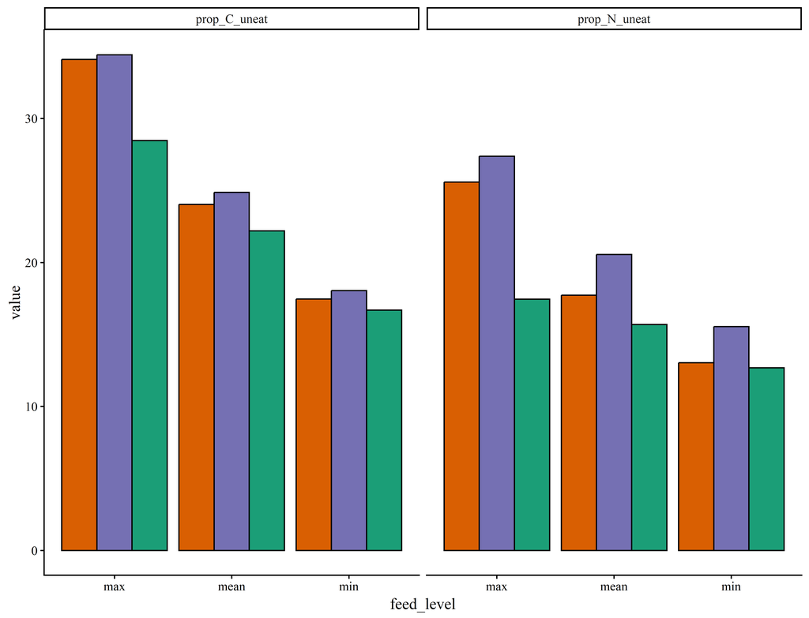

Figure 1: Proportion of C and N lost through uneaten feed, broken down by feed type and digestibility level.

```r
df %>%
  pivot_longer(cols = contains("prop"), names_to = "measure", values_to = "value") %>%
  ggplot(aes(x = feed_level, y = value, fill = feed)) +
  geom_col(colour = "black", position = position_dodge()) +
  scale_fill_manual(values = feed_pal) +
  facet_wrap(~measure) +
  prettyplot_300()
```

I wanted to know whether the proportion of C/N that comes from uneaten feed changed with temperature (latitutde). The answer is yes, but only because salmon stopped eating due to the temperatures in some farms, meaning that a higher proportion of feed was wasted (Figure 2).

**Plot proportion of C and N from uneaten feed against temperature**

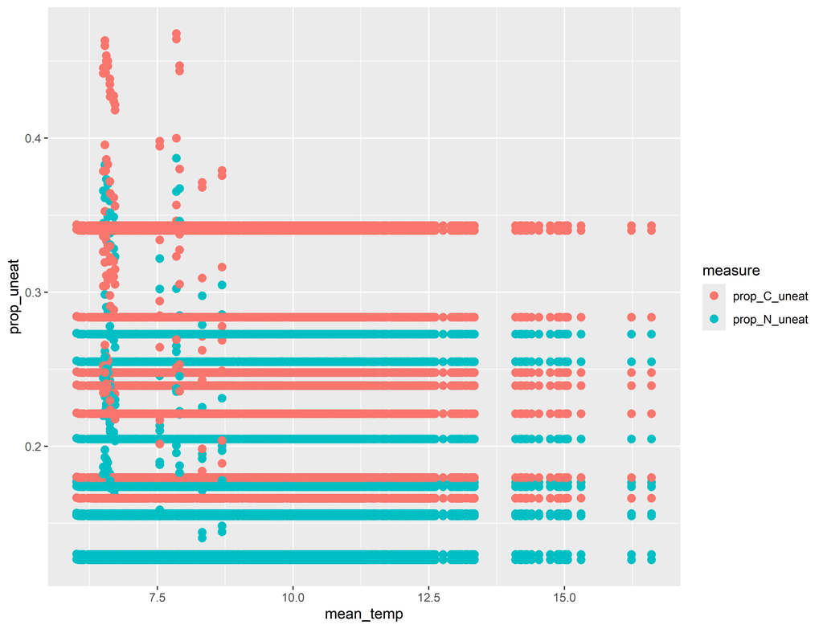

Figure 2: How the proportion of C and N from uneaten feed changes with temperature.

```r
temp <- full_join(
  farm_ends_carbon_parti, farm_ends_nitrogen_parti,
  by = join_by(feed, feed_level, farm_ID)
) %>%
  left_join(farm_locs, by = "farm_ID") %>%
  select(feed, feed_level, contains("prop"), mean_temp) %>%
  pivot_longer(
    cols = c(prop_C_uneat, prop_N_uneat),
    names_to = "measure", values_to = "prop_uneat"
  )

# lm1 <- lm(prop_C_uneat ~ mean_temp, data = filter(temp, measure == "prop_C_uneat"))
# summary(lm1)

ggplot(temp, aes(x = mean_temp, prop_uneat, colour = measure)) +
  geom_point(size = 2.5)
```

## 5.2 Feed digestibility

**Get a summary of constructed feeds**

```r
feed_params <- file.path(output_species_data_path, "feed_params_all.qs") %>%
  qread()
feed_names <- names(feed_params)

feed_params %>%
  map(function(ls) {
    ls %>%
      map2(., names(ls), function(df, m) {df %>% mutate(component = m)}) %>%
      bind_rows() %>%
      mutate(
        total = proportion * macro,
        digest_total = total * digest
      ) %>%
      group_by(component) %>%
      reframe(
        total = 100*sum(total),
        digest_total = 100*sum(digest_total)
      )
  }) %>%
  map2(., feed_names, function(df, fn) {df %>% mutate(feed = fn)}) %>%
  bind_rows() %>%
  convert_feeds_to_levels() %>%
  mutate(
    component = factor(component, levels = c("Proteins", "Lipids", "Carbohydrates"), labels = c("P", "L", "C")),
    feed = factor(feed, levels = c("marine_dominant_biomar", "plant_dominant_biomar", "animal_dominant_biomar"), labels = c("MD", "PD", "AD"))
  ) %>%
  pivot_wider(names_from = component, values_from = c(total, digest_total)) %>%
  relocate(total_C, .before = digest_total_C) %>%
  relocate(total_L, .before = digest_total_L) %>%
  relocate(digest_total_P, .after = total_P) %>%
  rename(digest_P = digest_total_P, digest_C = digest_total_C, digest_L = digest_total_L) %>%
  mutate(
    ADP = 100*digest_P/total_P,
    ADC = 100*digest_C/total_C,
    ADL = 100*digest_L/total_L
    ) %>%
  arrange(-feed_level, feed) %>%
  filter(feed == "PD") %>%
  gt() %>%
  fmt_number(
    columns = where(is.numeric),
    decimals = 1
  )
```

| feed | feed_level | total_P | digest_P | total_C | digest_C | total_L | digest_L | ADP | ADC | ADL |
| --- | --- | --- | --- | --- | --- | --- | --- | --- | --- | --- |
| PD | mean | 30.8 | 25.6 | 21.5 | 16.8 | 40.6 | 38.6 | 83.2 | 78.1 | 95.2 |
| PD | min | 30.8 | 24.2 | 21.5 | 16.0 | 40.6 | 36.7 | 78.5 | 74.1 | 90.4 |
| PD | max | 30.8 | 26.2 | 21.5 | 16.8 | 40.6 | 40.5 | 85.2 | 78.0 | 99.8 |

← Previous: Run Atlantic salmon model

Next: Exploring figures →